# J2 K=5 Spatial Niche Architecture Audit

Author

Codex

Published

October 8, 2026

```r
library(data.table)
library(knitr)

script_dir <- dirname(knitr::current_input(dir = TRUE))
project_dir <- normalizePath(file.path(script_dir, ".."), mustWork = TRUE)
result_dir <- file.path(
  project_dir,
  "results/reanalysis/J2_UNBIASED_NICHE_RESOLUTION_20261008_110522",
  "K05_SPATIAL_ARCHITECTURE_20261008_120148"
)

continuity <- fread(file.path(result_dir, "01_K05_NICHE_SPATIAL_CONTINUITY.tsv"))
adjacency_counts <- fread(file.path(result_dir, "02_K05_NICHE_ADJACENCY_COUNTS.tsv"))
patient_enrichment <- fread(file.path(
  result_dir,
  "04_K05_PATIENT_NICHE_ADJACENCY_ENRICHMENT.tsv"
))
cross_patient <- fread(file.path(
  result_dir,
  "05_K05_CROSS_PATIENT_ADJACENCY_SUMMARY.tsv"
))
continuity_summary <- fread(file.path(
  result_dir,
  "06_K05_CROSS_PATIENT_CONTINUITY_SUMMARY.tsv"
))
audit <- fread(file.path(
  result_dir,
  "08_K05_SPATIAL_ARCHITECTURE_FINAL_AUDIT.tsv"
))
evaluable_bin_n <- continuity[, unique(patient_evaluable_bin_n), by = patient_id][, sum(V1)]
unique_edge_n <- adjacency_counts[scope == "all_J2", unique(total_unique_edge_n)]
```

## Scope and provenance

This audit reuses the frozen Y40105J2 K=5 assignment. It does not rerun clustering or RCTD. The analysis includes all five niches symmetrically and all 10 heterotypic niche pairs.

- Neighborhood-evaluable Bin50: 58,772
- Patients: 7
- Patient/ROI-specific Queen edges: 218,614
- Direct adjacency: same patient and ROI, `abs(dx) <= 25 um` and `abs(dy) <= 25 um`, excluding self-pairs
- Null: 999 niche-label permutations within each patient and ROI

Frozen aggregate labels and boundaries were not read. Disease labels were used only for patient labels in figures. No disease-significance, DEG/GSEA, pathway, CellChat, ligand-receptor, or cross-chip consensus analysis was performed.

## Spatial niche maps

The complete seven-page map is stored at `figures/01_K05_ALL_PATIENT_SPATIAL_NICHE_MAPS_EN.pdf`. Each page uses the same K=5 color key, actual Bin50 coordinates, and a 25 x 25 um tile size.

## Connected components and fragmentation

```r
kable(
  continuity_summary,
  digits = 3,
  caption = "Cross-patient median K=5 spatial-continuity metrics"
)
```

Cross-patient median K=5 spatial-continuity metrics

| niche | median_largest_component_fraction | median_fragmentation_index | median_component_size |
| --- | --- | --- | --- |
| N2 | 0.169 | 0.831 | 2 |
| N4 | 0.109 | 0.891 | 2 |
| N1 | 0.100 | 0.900 | 1 |
| N5 | 0.090 | 0.910 | 1 |
| N3 | 0.067 | 0.933 | 2 |

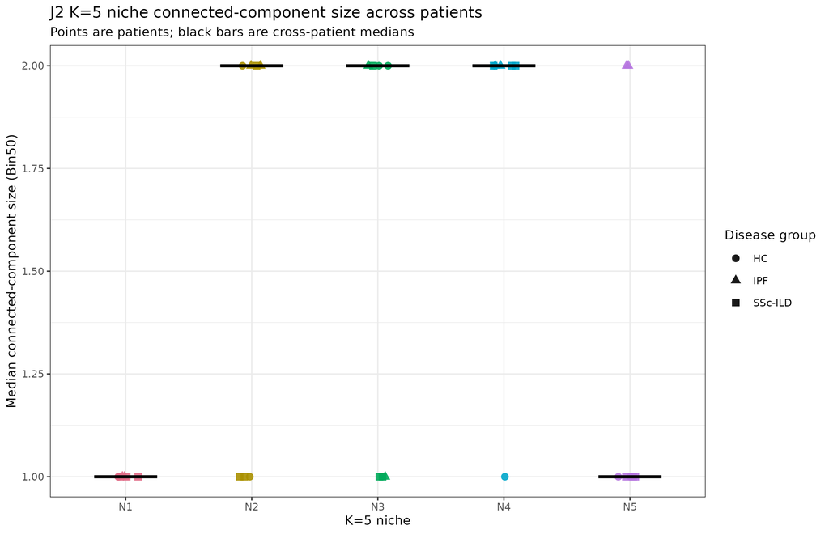

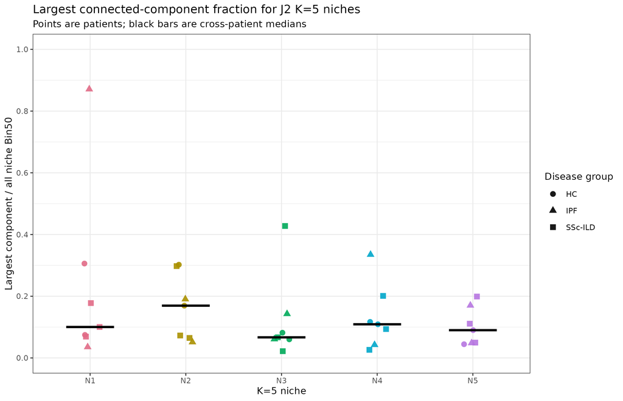

N2 had the highest cross-patient median largest-component fraction, followed by N4 and N1. Absolute largest-component fractions remained modest, indicating that every K=5 label occurred in multiple disconnected patches rather than one continuous tissue compartment.

## Direct niche adjacency

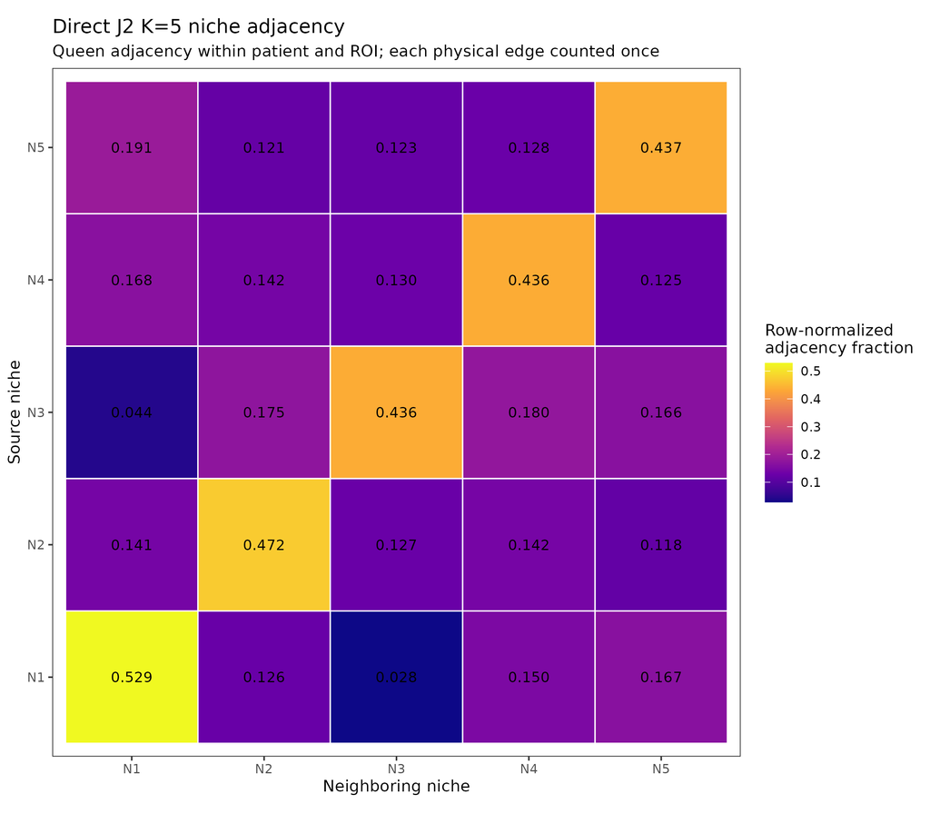

The diagonal captures strong homotypic adjacency. Because K=5 labels derive from overlapping 50 um neighborhood-composition profiles, high self-adjacency is expected and is not treated as independent biological validation.

## Cross-patient spatial consistency

```r
kable(
  cross_patient[, .(
    niche_pair,
    median_log2_enrichment,
    positive_patient_n,
    negative_patient_n,
    evaluable_patient_n,
    direction_consistency,
    max_absolute_share,
    single_patient_driven
  )],
  digits = 3,
  caption = "All 10 heterotypic K=5 niche-pair results"
)
```

All 10 heterotypic K=5 niche-pair results

| niche_pair | median_log2_enrichment | positive_patient_n | negative_patient_n | evaluable_patient_n | direction_consistency | max_absolute_share | single_patient_driven |
| --- | --- | --- | --- | --- | --- | --- | --- |
| N1-N3 | -2.066 | 0 | 7 | 7 | Negative in >=6/7 patients | 0.186 | FALSE |
| N4-N5 | -0.643 | 0 | 7 | 7 | Negative in >=6/7 patients | 0.254 | FALSE |
| N2-N4 | -0.571 | 0 | 7 | 7 | Negative in >=6/7 patients | 0.209 | FALSE |
| N2-N5 | -0.533 | 0 | 7 | 7 | Negative in >=6/7 patients | 0.254 | FALSE |
| N1-N2 | -0.348 | 0 | 7 | 7 | Negative in >=6/7 patients | 0.350 | FALSE |
| N1-N4 | -0.413 | 1 | 6 | 7 | Negative in >=6/7 patients | 0.357 | FALSE |
| N2-N3 | -0.328 | 1 | 6 | 7 | Negative in >=6/7 patients | 0.259 | FALSE |
| N3-N5 | -0.300 | 1 | 6 | 7 | Negative in >=6/7 patients | 0.300 | FALSE |
| N3-N4 | -0.295 | 1 | 6 | 7 | Negative in >=6/7 patients | 0.245 | FALSE |
| N1-N5 | -0.152 | 2 | 5 | 7 | Negative in 5/7 patients | 0.284 | FALSE |

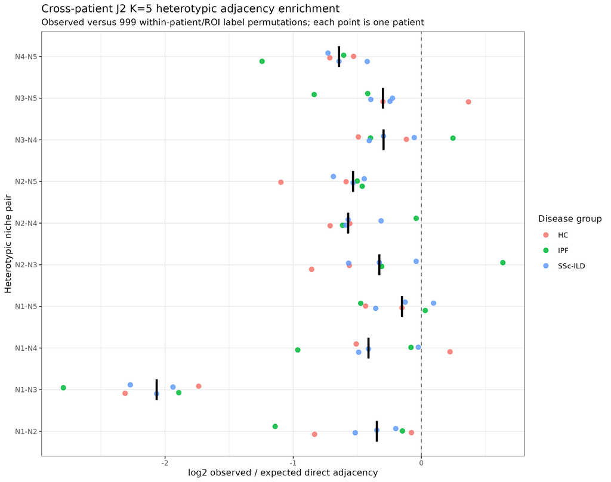

Nine of 10 heterotypic pairs retained a negative observed/expected direction in at least six of seven patients. No heterotypic pair showed recurrent positive enrichment. N1–N3 had the largest negative median displacement. These results describe spatial separation relative to an exchangeable-label null; they do not demonstrate cell-cell communication or causal exclusion.

## Validation and limitations

```r
kable(audit, caption = "Final spatial-architecture output audit")
```

Final spatial-architecture output audit

| item | value | passed |
| --- | --- | --- |
| chip | Y40105J2 | TRUE |
| K assignment source | /mnt/d/bb/博士课题组资料/新建文件夹/自己课题相关/Lung ST/codex agent/stereo_seq/stereo_seq/results/reanalysis/J2_UNBIASED_NICHE_RESOLUTION_20261008_110522/K05/02_BIN_NICHE_ASSIGNMENTS.tsv.gz | TRUE |
| evaluable Bin50 | 58772 | TRUE |
| not-evaluable Bin50 | 68 | TRUE |
| patients | 7 | TRUE |
| ROIs | 7 | TRUE |
| adjacency definition | Queen: same patient/ROI; \|dx\|<=25 um; \|dy\|<=25 um; no self-edge | TRUE |
| unique adjacency edges | 218614 | TRUE |
| heterotypic pair count | 10 | TRUE |
| permutation number | 999 | TRUE |
| permutation seed | 2026100811 | TRUE |
| frozen aggregate used | FALSE | TRUE |
| disease used in spatial definition | FALSE | TRUE |
| disease significance | FALSE | TRUE |
| DEG/GSEA | FALSE | TRUE |
| pathway | FALSE | TRUE |
| cell-cell communication | FALSE | TRUE |
| output::01_K05_NICHE_SPATIAL_CONTINUITY.tsv | /mnt/d/bb/博士课题组资料/新建文件夹/自己课题相关/Lung ST/codex agent/stereo_seq/stereo_seq/results/reanalysis/J2_UNBIASED_NICHE_RESOLUTION_20261008_110522/K05_SPATIAL_ARCHITECTURE_20261008_120148/01_K05_NICHE_SPATIAL_C… | TRUE |
| output::02_K05_NICHE_ADJACENCY_COUNTS.tsv | /mnt/d/bb/博士课题组资料/新建文件夹/自己课题相关/Lung ST/codex agent/stereo_seq/stereo_seq/results/reanalysis/J2_UNBIASED_NICHE_RESOLUTION_20261008_110522/K05_SPATIAL_ARCHITECTURE_20261008_120148/02_K05_NICHE_ADJACENCY… | TRUE |
| output::03_K05_NICHE_ADJACENCY_FRACTIONS.tsv | /mnt/d/bb/博士课题组资料/新建文件夹/自己课题相关/Lung ST/codex agent/stereo_seq/stereo_seq/results/reanalysis/J2_UNBIASED_NICHE_RESOLUTION_20261008_110522/K05_SPATIAL_ARCHITECTURE_20261008_120148/03_K05_NICHE_ADJACENCY… | TRUE |
| output::04_K05_PATIENT_NICHE_ADJACENCY_ENRICHMENT.tsv | /mnt/d/bb/博士课题组资料/新建文件夹/自己课题相关/Lung ST/codex agent/stereo_seq/stereo_seq/results/reanalysis/J2_UNBIASED_NICHE_RESOLUTION_20261008_110522/K05_SPATIAL_ARCHITECTURE_20261008_120148/04_K05_PATIENT_NICHE_A… | TRUE |
| output::05_K05_CROSS_PATIENT_ADJACENCY_SUMMARY.tsv | /mnt/d/bb/博士课题组资料/新建文件夹/自己课题相关/Lung ST/codex agent/stereo_seq/stereo_seq/results/reanalysis/J2_UNBIASED_NICHE_RESOLUTION_20261008_110522/K05_SPATIAL_ARCHITECTURE_20261008_120148/05_K05_CROSS_PATIENT_A… | TRUE |
| output::06_K05_CROSS_PATIENT_CONTINUITY_SUMMARY.tsv | /mnt/d/bb/博士课题组资料/新建文件夹/自己课题相关/Lung ST/codex agent/stereo_seq/stereo_seq/results/reanalysis/J2_UNBIASED_NICHE_RESOLUTION_20261008_110522/K05_SPATIAL_ARCHITECTURE_20261008_120148/06_K05_CROSS_PATIENT_C… | TRUE |
| output::07_K05_SPATIAL_ARCHITECTURE_FINDINGS_ZH.md | /mnt/d/bb/博士课题组资料/新建文件夹/自己课题相关/Lung ST/codex agent/stereo_seq/stereo_seq/results/reanalysis/J2_UNBIASED_NICHE_RESOLUTION_20261008_110522/K05_SPATIAL_ARCHITECTURE_20261008_120148/07_K05_SPATIAL_ARCHITE… | TRUE |
| output::README_ZH.md | /mnt/d/bb/博士课题组资料/新建文件夹/自己课题相关/Lung ST/codex agent/stereo_seq/stereo_seq/results/reanalysis/J2_UNBIASED_NICHE_RESOLUTION_20261008_110522/K05_SPATIAL_ARCHITECTURE_20261008_120148/README_ZH.md | TRUE |
| output::figures/01_K05_ALL_PATIENT_SPATIAL_NICHE_MAPS_EN.pdf | /mnt/d/bb/博士课题组资料/新建文件夹/自己课题相关/Lung ST/codex agent/stereo_seq/stereo_seq/results/reanalysis/J2_UNBIASED_NICHE_RESOLUTION_20261008_110522/K05_SPATIAL_ARCHITECTURE_20261008_120148/figures/01_K05_ALL_PAT… | TRUE |
| output::figures/02_K05_NICHE_COMPONENT_SIZE_EN.pdf | /mnt/d/bb/博士课题组资料/新建文件夹/自己课题相关/Lung ST/codex agent/stereo_seq/stereo_seq/results/reanalysis/J2_UNBIASED_NICHE_RESOLUTION_20261008_110522/K05_SPATIAL_ARCHITECTURE_20261008_120148/figures/02_K05_NICHE_C… | TRUE |
| output::figures/03_K05_NICHE_LARGEST_COMPONENT_FRACTION_EN.pdf | /mnt/d/bb/博士课题组资料/新建文件夹/自己课题相关/Lung ST/codex agent/stereo_seq/stereo_seq/results/reanalysis/J2_UNBIASED_NICHE_RESOLUTION_20261008_110522/K05_SPATIAL_ARCHITECTURE_20261008_120148/figures/03_K05_NICHE_L… | TRUE |
| output::figures/04_K05_NICHE_ADJACENCY_HEATMAP_EN.pdf | /mnt/d/bb/博士课题组资料/新建文件夹/自己课题相关/Lung ST/codex agent/stereo_seq/stereo_seq/results/reanalysis/J2_UNBIASED_NICHE_RESOLUTION_20261008_110522/K05_SPATIAL_ARCHITECTURE_20261008_120148/figures/04_K05_NICHE_A… | TRUE |
| output::figures/05_K05_CROSS_PATIENT_ADJACENCY_ENRICHMENT_EN.pdf | /mnt/d/bb/博士课题组资料/新建文件夹/自己课题相关/Lung ST/codex agent/stereo_seq/stereo_seq/results/reanalysis/J2_UNBIASED_NICHE_RESOLUTION_20261008_110522/K05_SPATIAL_ARCHITECTURE_20261008_120148/figures/05_K05_CROSS_P… | TRUE |

All 30 audit rows passed. The permutation checkpoint contains 105 patient-pair rows: seven patients multiplied by 15 total pair types, including 70 patient by heterotypic-pair observations. The initial run completed all seven permutation blocks and stopped during a downstream sort; the corrected continuation reused the saved complete permutation table and did not repeat the null calculation.

The label-permutation null disrupts endogenous spatial autocorrelation and does not preserve the overlap among adjacent 50 um input neighborhoods. Consequently, the audit supports organized niche-label fields and interface preferences, not independent validation of cell identities or interactions.